# PC Practical: Linear Regression I

## Exercise 16

For 96 fish (dojo loaches and goldfish) the resistance against the poison EI-43,064 was tested by placing each fish separately in a barrel with 2 liters of water and a certain dose (in mg) of the poison. Next to the survival time in minutes (the outcome, ‘minsurv’) the weight of the fish (in gram) was measured. The research questions are ‘What is the association between dose and survival time?’, ‘Will, for the same dose, a higher weight of the fish yield a higher survival time?’, ‘Are dojo loaches more resistant to the poison?’, and finally ‘Is the effect of the dose on the survival time different for dojo loaches and goldfish?’. We will try to answer these questions in this practical.

First read in the dataset poison.dat. Read in the dataset via `read.csv`. Change the directory to the folder where `poison.dat` is saved.

```r
poison <- read.csv("poison.dat", sep="")
attach(poison)
```

### Problem 1: simple linear regression

**Simple Linear Regressions is regression where the dependent variable is modelled in function of only 1 independent variable, i.e., linear regression of the form $E(Y_i) = \beta_0 + \beta_1X_i$ (here $E$ stands for the expected value). In this representation $Y$ is the dependent variable (or response) and $X$ the independent variable (or predictor).**

### In this part we will try to answer the first research question “What is the association between dose and survival time?”

#### 1. Make an appropriate plot to look at the association between dose and survival time

Verify whether it is realistic to assume a linear association between dose and survival time by first drawing the best fitting curve to the point cloud and then also the best fitting line.

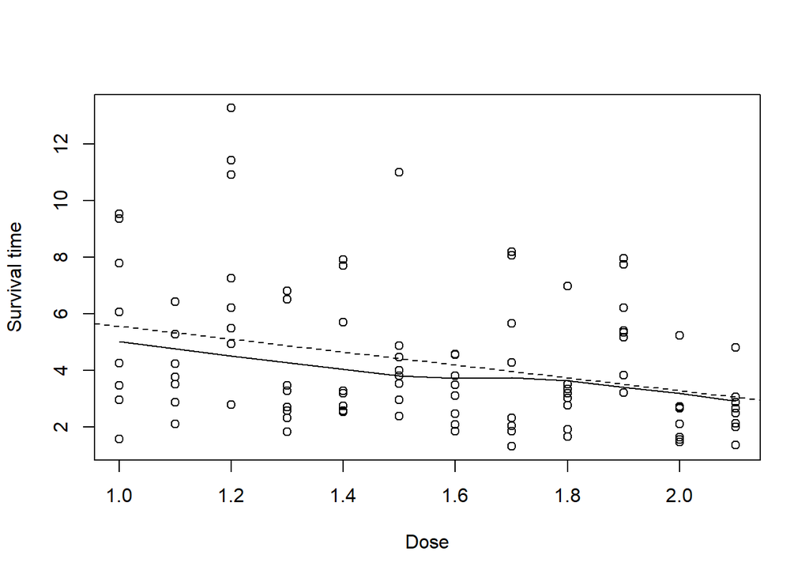

```r
plot(x = dose, y = minsurv, xlab = "Dose", ylab = "Survival time")
# Fit a curve through the points cloud (solid line)
lines(lowess(dose, minsurv), lty = 1)  # lty = 1 draws a solid line
# Fit a line through the point cloud using least squares method (dotted line)
abline(lsfit(dose, minsurv), lty = 2) # lty = 2 draws a dotted line, If this option is not specified, a solid line is drawn
```

The curve approximates relatively well a line. Based on the figure, we can conclude that it is realistic to assume a linear association between `minsurv` and `dose`.

#### 2. Postulate, based on the previous plot, a meaningful model for the mean survival time in function of the dose

Model:

$minsurv_i = \beta_0 + \beta_1 dose_i + \epsilon_i$

where $E$ stands for the expected value.

#### 3. Perform a linear regression analysis to estimate the parameters in the model.

```r
# Fit a linear regression model using 'minsurv' as dependent and 'dose' as dependent variable

# To obtain only the estimated coefficients of the linear regression model, use the command
model <- lm(minsurv ~ dose)
# If, next to that, you would also like to know (among others) the standard errors and p-values of these estimates, use the command
summary(model)
```

```
##
## Call:
## lm(formula = minsurv ~ dose)
##
## Residuals:
##     Min      1Q  Median      3Q     Max
## -3.9857 -1.7536 -0.5846  1.2407  8.1620
##
## Coefficients:
##             Estimate Std. Error t value Pr(>|t|)
## (Intercept)   7.8187     1.1231   6.961  4.5e-10 ***
## dose         -2.2672     0.7073  -3.206  0.00184 **
## ---
## Signif. codes:  0 '***' 0.001 '**' 0.01 '*' 0.05 '.' 0.1 ' ' 1
##
## Residual standard error: 2.392 on 94 degrees of freedom
## Multiple R-squared:  0.09854,    Adjusted R-squared:  0.08895
## F-statistic: 10.28 on 1 and 94 DF,  p-value: 0.001842
```

**Assumptions of linear regression:**

- Independent observations
- Normally distributed residuals
- Linearity between response and predictor (implies that the residuals are distributed around zero)
- Homoscedasticity

##### Verify at the same time the assumptions that are needed to perform this analysis and trust its results.

##### a) Is the assumption of linearity realistic? This can be verified in 2 ways. The first one is by using the scatterplot we made in question 1. If the curve is more or less linear, you can conclude that the linearity assumption seems realistic. A better way is to make a residual plot and check if the points in this plot are randomly scattered around the line Y = 0. You cannot see any relation between the fitted values (or the predictor values) and the residuals. A residual plot is a scatterplot with on the X-axis the fitted values (or predictor values), and on the Y -axis the residuals. These values can be retrieved by the commands *fitted(model)* and *resid(model)*

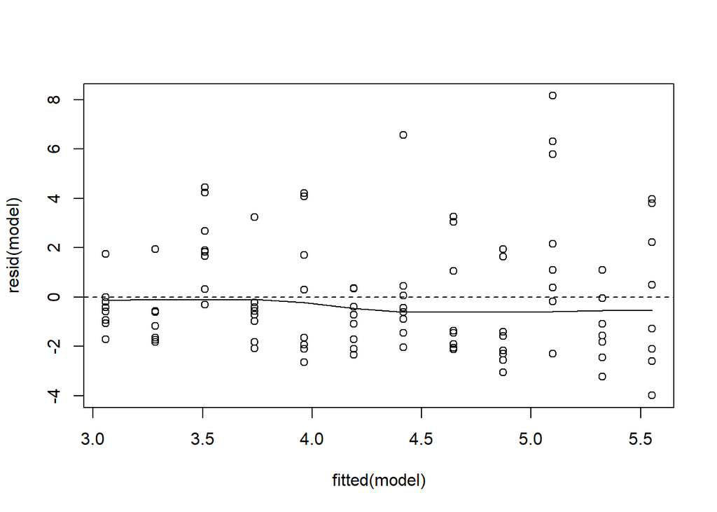

```r
# Assumptions OK?
# a. Linearity:
# A scatterplot of these values, with a horizontal line through 0 (h=0) and the best fitting curve, is obtained by
plot(fitted(model), resid(model))
lines(lowess(fitted(model), resid(model)))
abline(h = 0, lty = 2)
```

If the curve approximates the horizontal line relatively well, the can conclude that the linearity assumption holds.

##### b) Is the assumption of homoscedasticity met?

To verify this, we make a scatterplot of the squared residuals in function of the fitted values (or predictor values): *plot(fitted(model), resid(model)ˆ2)*

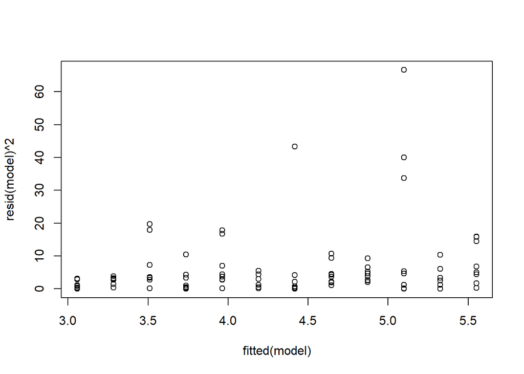

```r
# b. Homoscedasticity: doubtful...
plot(fitted(model), resid(model)^2)
```

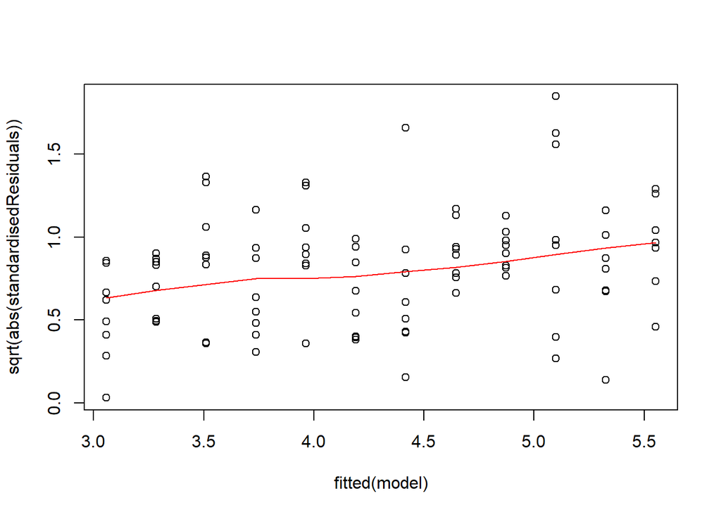

```r
standardisedResiduals = resid(model)/summary(model)$sigma
plot(x = fitted(model), y = sqrt(abs(standardisedResiduals)))
lines(lowess(x = fitted(model), y = sqrt(abs(standardisedResiduals))), col = "red")
```

##### c) Are the residuals normally distributed? This will be verified using a QQ-plot for the residuals

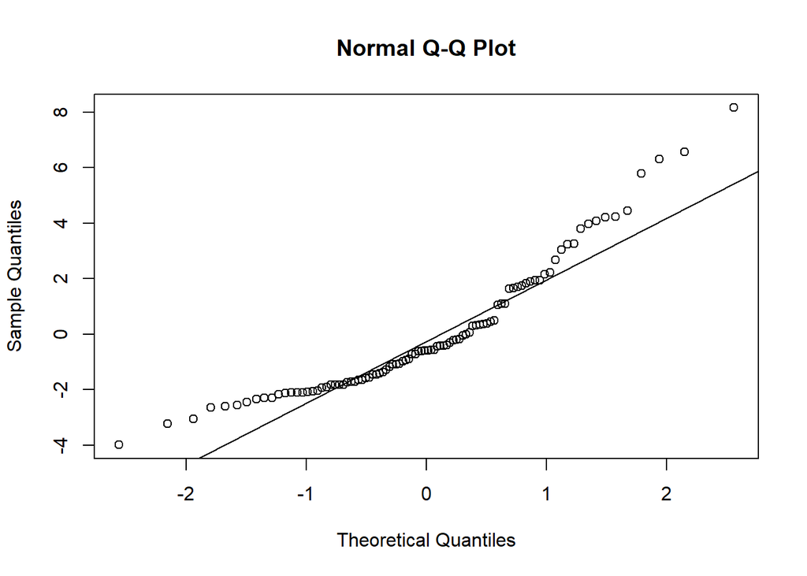

```r
# c. Normally distributed residuals:
qqnorm(resid(model))
qqline(resid(model)) # long tail on right + short tail on left. Not really OK
```

Plot all diagrams together:

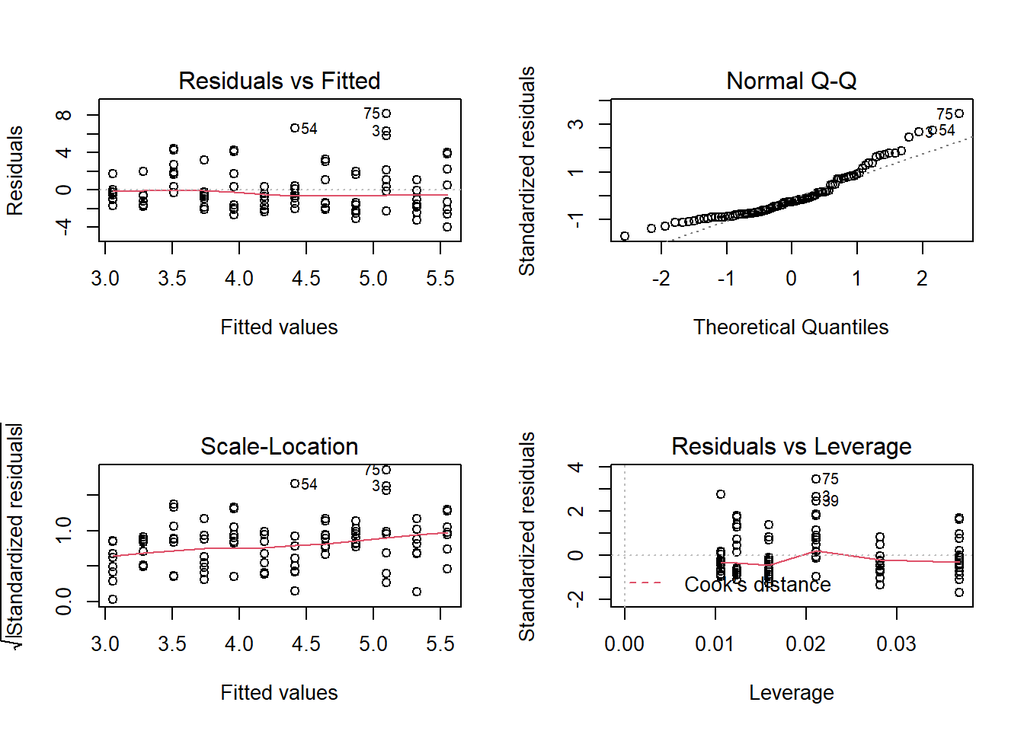

```r
# Checking multiple assumptions simultaneously for a model:
par(mfrow=c(2,2))
plot(model)
```

**The assumption of homoscedasticity is doubtful and the residuals do not follow a normal distribution. We could transform the dependent variable in hope of meeting the assumptions after all.**

#### 4. If not all the previous assumptions hold, an appropriate transformation of either the dependent or the independent variable has to be applied and a linear regressions analysis on the transformed variable(s) has to be performed. Verify if here all the assumptions hold.

Try for yourself certain transformations of the dependent `minsurv` variable, refit a linear regression model and check if the assumptions seem more plausible. Common transformations are the square root, the inverse and the logarithmic transformation.

#### 5. If all assumptions hold, write down the final model for the mean outcome with the estimated regression coefficients and interpret this model (both on the scale of the transformed values as on the original scale).

**For the log-transformation:**

Interpretation on the scale of the transformed values:

…

Interpretation on the original scale:

…

#### 6. Give a 95% confidence interval for the effect of the dose on the expected outcome and test if this effect is significantly different from 0 at the 5% significance level. In R we retrieve this interval by *condint(model)*

```r
log.minsurv <- log(minsurv)
logModel <- lm(log.minsurv ~ dose)
confint(logModel) # 95% CI
```

```
##                 2.5 %     97.5 %
## (Intercept)  1.628792  2.5804330
## dose        -0.810830 -0.2115505
```

```r
summary(logModel) # p-value for tests vs 0
```

```
##
## Call:
## lm(formula = log.minsurv ~ dose)
##
## Residuals:
##      Min       1Q   Median       3Q      Max
## -1.14507 -0.38506 -0.06518  0.37175  1.09357
##
## Coefficients:
##             Estimate Std. Error t value Pr(>|t|)
## (Intercept)   2.1046     0.2396   8.782 7.13e-14 ***
## dose         -0.5112     0.1509  -3.387  0.00103 **
## ---
## Signif. codes:  0 '***' 0.001 '**' 0.01 '*' 0.05 '.' 0.1 ' ' 1
##
## Residual standard error: 0.5104 on 94 degrees of freedom
## Multiple R-squared:  0.1088, Adjusted R-squared:  0.0993
## F-statistic: 11.47 on 1 and 94 DF,  p-value: 0.001032
```

Note the link between CI and p-value!

#### 7.Perform a variance analysis and interpret the obtained p-value

```r
anova(logModel)
```

```
## Analysis of Variance Table
##
## Response: log.minsurv
##           Df  Sum Sq Mean Sq F value   Pr(>F)
## dose       1  2.9894 2.98945  11.474 0.001032 **
## Residuals 94 24.4908 0.26054
## ---
## Signif. codes:  0 '***' 0.001 '**' 0.01 '*' 0.05 '.' 0.1 ' ' 1
```

**How do we interpret the p-value?** …

#### 8. Estimate the geometric mean of the survival time for a dose of 2 mg. Give the accompanying 95% confidence interval.

```r
# To obtain this confidence interval, you first create a new dataset (call this poison2) with 1 variable that you call ‘dose’ for which you enter in observation, namely 2.

poison2 <- data.frame(dose = c(2))
# Prediction on the log scale: predict mean(log(y))
predict(logModel, poison2, interval = "c") # interval = "c" indicates we want to obtain confidence intervals
```

```
##        fit       lwr      upr
## 1 1.082232 0.9122891 1.252174
```

```r
# Geometric mean: exp(mean(log(y)))
exp(predict(logModel, poison2, interval = "c"))
```

```
##        fit      lwr      upr
## 1 2.951259 2.490016 3.497941
```

Remark that $e^{0.9122891}=2.490016$ and $e^{1.252174}=3.497941$.

#### 9. What can we conclude from the multiple correlation coefficient?

```r
summary(logModel)
```

```
##
## Call:
## lm(formula = log.minsurv ~ dose)
##
## Residuals:
##      Min       1Q   Median       3Q      Max
## -1.14507 -0.38506 -0.06518  0.37175  1.09357
##
## Coefficients:
##             Estimate Std. Error t value Pr(>|t|)
## (Intercept)   2.1046     0.2396   8.782 7.13e-14 ***
## dose         -0.5112     0.1509  -3.387  0.00103 **
## ---
## Signif. codes:  0 '***' 0.001 '**' 0.01 '*' 0.05 '.' 0.1 ' ' 1
##
## Residual standard error: 0.5104 on 94 degrees of freedom
## Multiple R-squared:  0.1088, Adjusted R-squared:  0.0993
## F-statistic: 11.47 on 1 and 94 DF,  p-value: 0.001032
```

#### 10.Perform an appropriate test to see is the dose effect is nonlinear (e.g., quadratic). To this end we first create a new variable containing the squares of the doses and then add this variable as a predictor to the linear regression model we already had.

```r
sqdose <- dose^2
logModel2 <- lm(log.minsurv ~ dose + sqdose)
summary(logModel2)
```

```
##
## Call:
## lm(formula = log.minsurv ~ dose + sqdose)
##
## Residuals:
##      Min       1Q   Median       3Q      Max
## -1.10151 -0.41100 -0.06467  0.35840  1.09436
##
## Coefficients:
##             Estimate Std. Error t value Pr(>|t|)
## (Intercept)   1.5621     1.1578   1.349    0.181
## dose          0.2254     1.5451   0.146    0.884
## sqdose       -0.2376     0.4960  -0.479    0.633
##
## Residual standard error: 0.5125 on 93 degrees of freedom
## Multiple R-squared:  0.111,  Adjusted R-squared:  0.09186
## F-statistic: 5.805 on 2 and 93 DF,  p-value: 0.004211
```

**Is it useful to add a quadratic effect?**

#### 11. Perform for this new model again a variance analysis and interpret the p-value

```r
anova(logModel2)
```

```
## Analysis of Variance Table
##
## Response: log.minsurv
##           Df  Sum Sq Mean Sq F value   Pr(>F)
## dose       1  2.9894 2.98945 11.3800 0.001084 **
## sqdose     1  0.0603 0.06029  0.2295 0.633025
## Residuals 93 24.4305 0.26269
## ---
## Signif. codes:  0 '***' 0.001 '**' 0.01 '*' 0.05 '.' 0.1 ' ' 1
```

Performing ANOVA on a multiple regression model will **sequentially** test the predictors.

p-value for `dose`: “Does the variable dose explain a significant proportion of the variation in the response variable?”

**Interpretation of the p-value for `dose’** …

p-value for `I(dose^2)`: “Does the square of the variable dose explain a significant proportion of the variation in the response variable **given that the variable dose is already included in the model**?”

**Interpretation of the p-value for `I(dose^2)’** …

### Problem 2: multiple linear regression

In this problem we will construct a multivariate linear regression model to formulate an answer for the remaining research questions ‘Will, for the same dose, a higher weight of the fish yield a higher survival time?’, ‘Are dojo loaches more resistant to the poison?’, and ‘Is the effect of the dose on the survival time different for dojo loaches and goldfish?’.

#### 1. Fit 2 regression models: 1 with the dose and weight and 1 with dose and the type of fish. Check which variable (`weight` or `type`) has the largest $t$-value and keep this variable in the model, on condition that that variable is significantly associated with the outcome. Then verify whether the other variable has an additional significant effect.

```r
log.minsurv <- log(minsurv)
modela <- lm(log.minsurv ~ dose + weight)
modelb <- lm(log.minsurv ~ dose + type)
summary(modela)
```

```
##
## Call:
## lm(formula = log.minsurv ~ dose + weight)
##
## Residuals:
##      Min       1Q   Median       3Q      Max
## -0.84338 -0.26778  0.02752  0.25525  0.90051
##
## Coefficients:
##             Estimate Std. Error t value Pr(>|t|)
## (Intercept)  -0.1762     0.2999  -0.588    0.558
## dose         -0.5557     0.1092  -5.088 1.87e-06 ***
## weight        1.1228     0.1205   9.319 5.65e-15 ***
## ---
## Signif. codes:  0 '***' 0.001 '**' 0.01 '*' 0.05 '.' 0.1 ' ' 1
##
## Residual standard error: 0.369 on 93 degrees of freedom
## Multiple R-squared:  0.5391, Adjusted R-squared:  0.5292
## F-statistic: 54.39 on 2 and 93 DF,  p-value: 2.273e-16
```

```r
summary(modelb)
```

```
##
## Call:
## lm(formula = log.minsurv ~ dose + type)
##
## Residuals:
##      Min       1Q   Median       3Q      Max
## -0.93444 -0.26305 -0.00796  0.24334  0.88449
##
## Coefficients:
##             Estimate Std. Error t value Pr(>|t|)
## (Intercept)  1.94648    0.17614  11.051  < 2e-16 ***
## dose        -0.59474    0.11076  -5.370 5.78e-07 ***
## type         0.70802    0.07785   9.095 1.68e-14 ***
## ---
## Signif. codes:  0 '***' 0.001 '**' 0.01 '*' 0.05 '.' 0.1 ' ' 1
##
## Residual standard error: 0.3733 on 93 degrees of freedom
## Multiple R-squared:  0.5283, Adjusted R-squared:  0.5182
## F-statistic: 52.08 on 2 and 93 DF,  p-value: 6.692e-16
```

…

…

#### 2. Investigate if there are significant higher order terms (interactions and/or quadratic effects).

**Is a quadratic effect for weight needed?**

```r
sqrweight <- weight^2
modeld <- lm(log.minsurv ~ dose + weight + sqrweight + type)
summary(modeld)
```

```
##
## Call:
## lm(formula = log.minsurv ~ dose + weight + sqrweight + type)
##
## Residuals:
##      Min       1Q   Median       3Q      Max
## -0.74215 -0.18977 -0.03255  0.20665  0.61629
##
## Coefficients:
##             Estimate Std. Error t value Pr(>|t|)
## (Intercept)  1.31835    0.95143   1.386    0.169
## dose        -0.60304    0.08439  -7.146 2.16e-10 ***
## weight      -0.16855    0.91668  -0.184    0.855
## sqrweight    0.23980    0.21993   1.090    0.278
## type         0.51099    0.06388   7.999 3.85e-12 ***
## ---
## Signif. codes:  0 '***' 0.001 '**' 0.01 '*' 0.05 '.' 0.1 ' ' 1
##
## Residual standard error: 0.2844 on 91 degrees of freedom
## Multiple R-squared:  0.7321, Adjusted R-squared:  0.7204
## F-statistic: 62.18 on 4 and 91 DF,  p-value: < 2.2e-16
```

**Is there an interaction between dose and type?**

```r
modele <- lm(log.minsurv~ dose + weight + type + dose:type)
summary(modele) #not significant -> leave interaction out of model
```

```
##
## Call:
## lm(formula = log.minsurv ~ dose + weight + type + dose:type)
##
## Residuals:
##      Min       1Q   Median       3Q      Max
## -0.75890 -0.20461 -0.02772  0.20825  0.58805
##
## Coefficients:
##             Estimate Std. Error t value Pr(>|t|)
## (Intercept)  0.34097    0.25346   1.345    0.182
## dose        -0.62511    0.10525  -5.939 5.17e-08 ***
## weight       0.82747    0.10086   8.204 1.45e-12 ***
## type         0.41863    0.28856   1.451    0.150
## dose:type    0.05962    0.17870   0.334    0.739
## ---
## Signif. codes:  0 '***' 0.001 '**' 0.01 '*' 0.05 '.' 0.1 ' ' 1
##
## Residual standard error: 0.2861 on 91 degrees of freedom
## Multiple R-squared:  0.729,  Adjusted R-squared:  0.7171
## F-statistic: 61.19 on 4 and 91 DF,  p-value: < 2.2e-16
```

…

Final model:

```r
model_final <- lm(log.minsurv ~ dose + weight + type)
```

The model selection procedure which we used here is called “forward selection”: we add variables to the model to see if they are significant. If this is the case we leave them in the model, if not we leave them out. In every step we look at different terms and keep the most significant (highest $t$-value or smallest $p$-value).

#### 3. Report the final model with the regression coefficients and verify the assumptions made for applying this regression analysis.

**Check all the assumptions!**

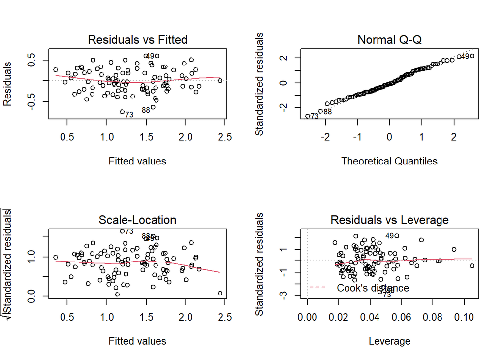

```r
par(mfrow=c(2,2))
plot(model_final)
```

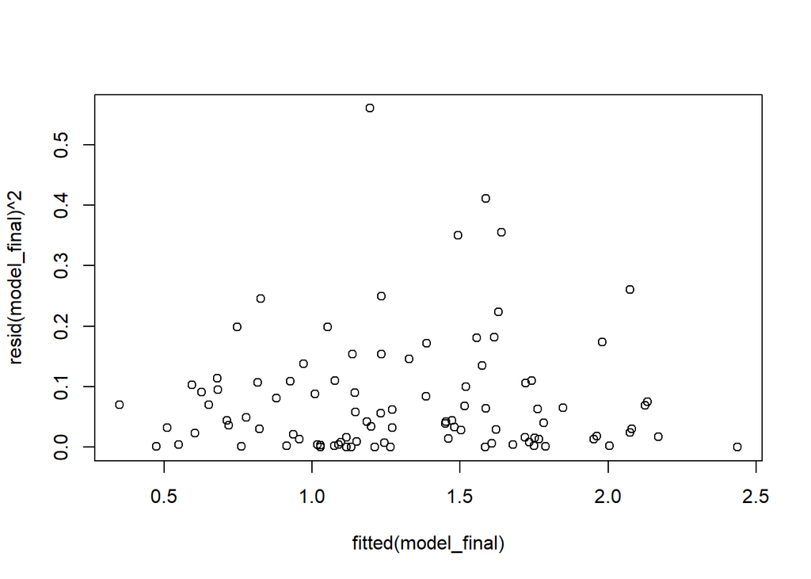

```r
par(mfrow=c(1,1))
plot(x=fitted(model_final),y=resid(model_final)^2)
```

…

#### 4. Interpret the estimated parameters, in other words, describe to what extent the dose, the weight of the fish, and the type of fish have an influence on the survival time of the fish.

```r
summary(model_final)
```

```
##
## Call:
## lm(formula = log.minsurv ~ dose + weight + type)
##
## Residuals:
##      Min       1Q   Median       3Q      Max
## -0.74846 -0.20506 -0.02398  0.19693  0.59625
##
## Coefficients:
##             Estimate Std. Error t value Pr(>|t|)
## (Intercept)  0.31425    0.23930   1.313    0.192
## dose        -0.60435    0.08447  -7.154 1.98e-10 ***
## weight       0.82498    0.10010   8.242 1.13e-12 ***
## type         0.51248    0.06393   8.016 3.34e-12 ***
## ---
## Signif. codes:  0 '***' 0.001 '**' 0.01 '*' 0.05 '.' 0.1 ' ' 1
##
## Residual standard error: 0.2847 on 92 degrees of freedom
## Multiple R-squared:  0.7286, Adjusted R-squared:  0.7198
## F-statistic: 82.35 on 3 and 92 DF,  p-value: < 2.2e-16
```

- 1. Interpretation of the dose estimate:

For fish of **the same species** and **the same weight** the mean of the natural logarithm of the survival time is estimated to decrease with 0.6, with every increase of the dose of the poison with 1 mg.

- Or after backtransformation:

…

- 2. Interpretation of the weight estimate:

For fish which weigh 1 gram more than the other fish of **the same species** and which were treated with **the same dose of poison**, the mean natural logarithm of the survival time is estimated to be 0.82 higher.

- Or after backtransformation:

…

- 3. Interpretation of the type estimate (given that 0 codes for dojo loaches and 1 for goldfish):

…

- Or after backtransformation:

…

#### 5. What can you conclude from the multiple correlation coefficient?

The multiple correlation coefficient $R^2$ is:

$R^2 = \frac{SS_{Regression}}{SS_{Total}}$

In the final model the multiple correlation coefficient is equal to 0.73. This means that …